# SLNB-Data

LU

2023-01-07

# Summaries of our Data

We have altogether 133 patients. Among them are 93 females and 40 males.

## Hospitalizations by Month

For each patient find the month when s/he was hospitalized (stacionēšanas datuma mēnesis). Our test data cover the entire year 2015, so our selection should not be *biased by month* (nav sistemātiskas novirzes - visiem gada mēnešiem bija vienādas izredzes nonākt datu izlasē). We still do have a tiny bias, since not all months have equal number of days, but we ignore that.

Draw a barplot - the number of patients by month. (Joslu diagramma.)

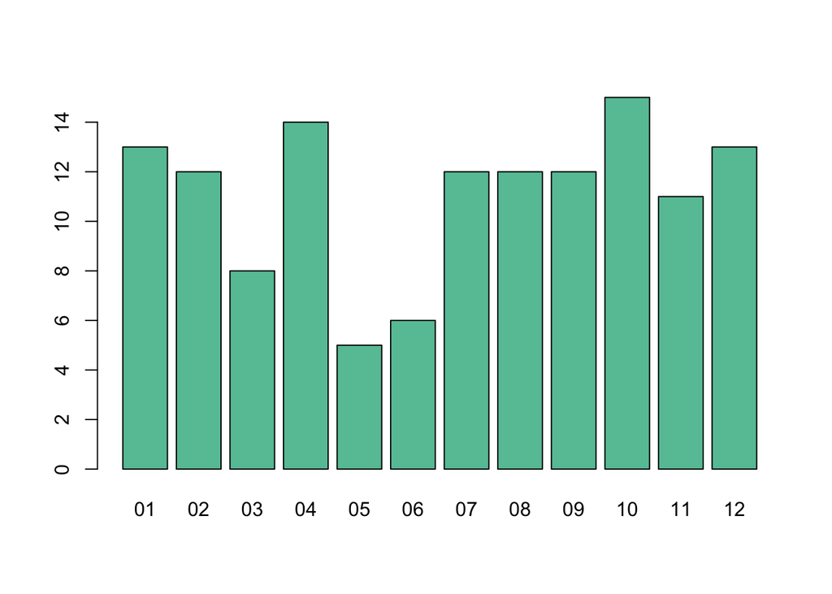

We formulate null hypothesis as follows: “Hospitalization months can be assumed to be uniform - there are no months that are overrepresented or underrepresented”.

(There could be reasons why null hypothesis could fail (if patients undergo more testing immediately beforeor after their summer vacations; or, perhaps, they were scheduled to a different month during their initial registration procedure).)

Our data cannot disprove the null hypothesis (cannot find any difference from the uniform distribution). We calculate [Pearson chi-squared test](https://en.wikipedia.org/wiki/Pearson%27s_chi-squared_test#Calculating_the_test-statistic) to find out the difference between actual data and the theoretical/uniform distribution.

```r
# our actual patients per month (January to December)
patientsByMonth <- as.vector(table(df2$month))
# distribution, if the distribution is uniform
uniformByMonth <- rep(133/12, rep=12)
chiSquareExpr <- sum((patientsByMonth - uniformByMonth)^2/uniformByMonth)
chiSquareExpr
```

```
## [1] 9.646617
```

```r
# Find the probability for 12-1 = 11 degrees of freedom
dchisq(chiSquareExpr, df=11)
```

```
## [1] 0.09129136
```

If the number of observations were considerably larger, we could, in fact, notice small differences between months.

**Brief Summary:** Our data set is insufficiently large to find any deviation from the uniform distribution of hospitalizations by month (i.e. zero hypthesis - assumption that all months are equally likely).

## Survival Data

In this section we draw some Kaplan-Meier diagrams see [Survival analysis by R](https://rviews.rstudio.com/2017/09/25/survival-analysis-with-r/) and other survival-related correlations.

**Definition:** Progression-Free Survival (days): Time interval from the first hospitalization (assumed to be approximately the same as the time of the first operation) to a progression event. (Since we do not know the progression event date, we assume that all these events happen on December 31 of the year that is specified in the column “Notikums”.)

**Definition:** Every patient who has Progression-Free Survival more than 7 years (or 2555 days) is considered to have 7 year survival without progression.

### Kaplan Meier Graph

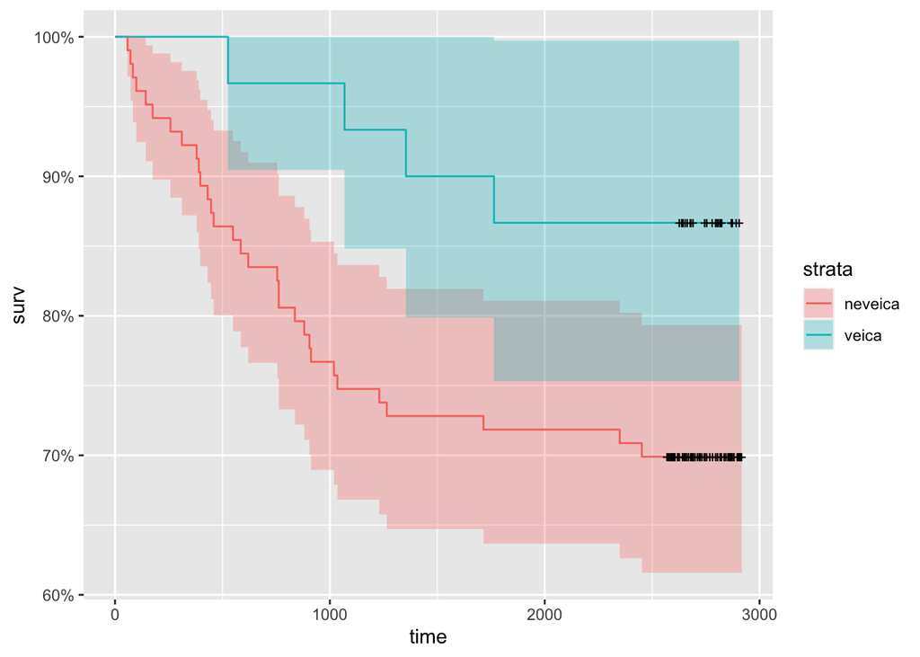

Chi-squared criterion - what is our confidence that undergoing the sentinel lymph node biopsy (SLNB) does indeed improve the survival time has not been done yet.

### How SLNB relates to PFS of More Than 7 Years

Some sources define *Functional Cure* of melanoma, if progression-free survival is at least 7 years. It makes sense to count the patients in all 4 possible groups. See the table below:

| Outcome: | More than 7 years PFS | No more than 7 year PFS. |
| --- | --- | --- |
| with SLNB | 26 | 4 |
| without SLNB | 72 | 31 |

- As the table shows, there is a 26/(26 + 4) = 86.67% proportion to survive, if SLNB was done.
- Also, there is a 72/(72 + 31) = 69.9% proportion to survive, if SLNB was **not** done.

Let us formulate two hypotheses:

- **Zero Hypothesis:** SLNB has no effect upon PFS of more than 7 years.
- **Alternative Hypothesis:** Doing SLNB should increase the proportion of patients having PFS of more than 7 years.

```r
fisher.test(rbind(c(slnbYESsurvivalYES,slnbYESsurvivalNO),c(slnbNOsurvivalYES,slnbNOsurvivalNO)), alternative="greater")
```

```
##
##  Fisher's Exact Test for Count Data
##
## data:  rbind(c(slnbYESsurvivalYES, slnbYESsurvivalNO), c(slnbNOsurvivalYES, slnbNOsurvivalNO))
## p-value = 0.05019
## alternative hypothesis: true odds ratio is greater than 1
## 95 percent confidence interval:
##  0.9991041       Inf
## sample estimates:
## odds ratio
##       2.78
```

As the Fisher test shows, p-value (0.05019) is slightly more than 5%, so we cannot reject Zero Hypothesis.

### Chi-Squared Test

Since Fisher’s test was very close, we could also try Pearson’s Chi-Squared to see, if it can give us better significance level.

```r
chisq.test(df2$hasSLNB, df2$survived, correct=FALSE)
```

```
##
##  Pearson's Chi-squared test
##
## data:  df2$hasSLNB and df2$survived
## X-squared = 3.3671, df = 1, p-value = 0.06651
```

Unfortunately, the significance level (0.06651) is even higher than the Fisher’s test. For a slightly larger set of patients we could reject the Zero Hypothesis.

One might think that SLNB is just a diagnostic procedure that by itself does not improve anyone’s chances. On the other hand, the very fact that it was done likely indicates that the patient has more resources or motivation to receive medical treatment, which improves the chances to survive.

## Breslow’s Depth and Survival Time

There are 98 patients with their survival time (*bezprogresijas dzīvildze*) unknown - they have no further progression events for their illness or, perhaps, are *censored data* (izvākti jeb nepilnīgi novērojumu dati). They are shown as dots at the top of the correlation diagram, but their data is not used to compute Pearson’s correlation.

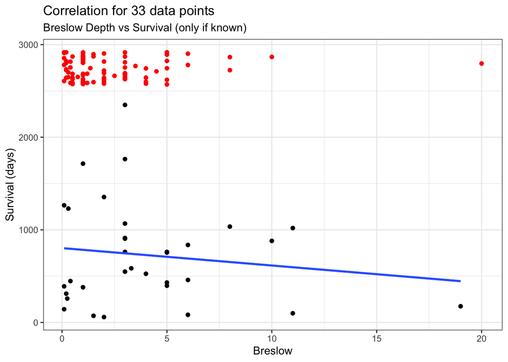

Numeric value of Pearson Correlation coefficient:

```r
result <- cor(dfCleared$BreslowNum, dfCleared$time, method = "pearson")

# Print the result
cat("Pearson correlation coefficient is:", result)
```

```
## Pearson correlation coefficient is: -0.1411406
```

This correlation is very weak, but it does not account for the fact that there are considerably more patients with low Breslow Depths who are still surviving (and their exact survival time is not known). If we set their survival time to be December 31, 2022, we get a different picture:

```r
missingPoints0 <- which(is.na(df2$BreslowNum))
dfCleared0 <- df2[setdiff(1:nrow(df), missingPoints0),]
dfMissing0 <- df2[missingPoints0,]


result <- cor(dfCleared0$BreslowNum, dfCleared0$time, method = "pearson")

# Print the result
cat("Pearson correlation coefficient is:", result)
```

```
## Pearson correlation coefficient is: -0.2562638
```

As the actual survival times become known, the correlation coefficient is likely to take an even more negative value.

## Clark Levels and Survival

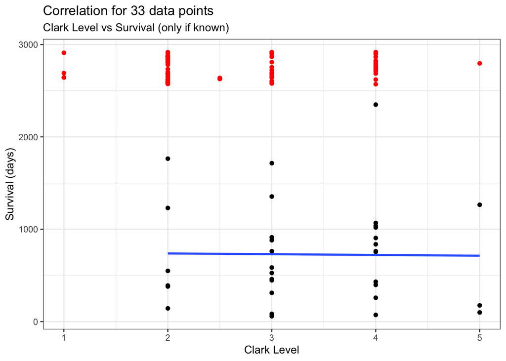

With Clark Level the situation is similar to Breslow Depth: It has very little effect upon those patients who had survival time less than some 3000 days; on the other hand there are considerably more people with low Clark Levels who are still surviving.

## Ulceration Levels

The values are almost always “ir” or “nav”. There are few exceptions resolved like this:

- “nav un ir desmoplāzija” was converted to “nav” (value = 0),
- “ir un ir desmoplāzija” was converted to “ir” (value = 2),
- “nav bet pie epikrīzes bija ka makroskopiski ir 0,5 cm izčūlojums” was converted to “nav” (value = 0)
- “nav???2aja histoloģija bija” was converted to “unknown” (value = 1)
- “nav aprakstīts” was converted to “unknown” (value = 1)

Drawing correlation line when there are only two values (“ir” vs. “nav” and a few unknowns) would not be helpful, but for each category (“ir”, “nav” or “unknown”), we can draw the distribution of survival (in days).

Šeit ir diagramma, kur atzīmētas kvartiles (daži punkti tur, kur ulcerācijas nav, bet dzīves ilgums ir mazāks par 2400 ir “outliers” - stipri novirzīti dati).

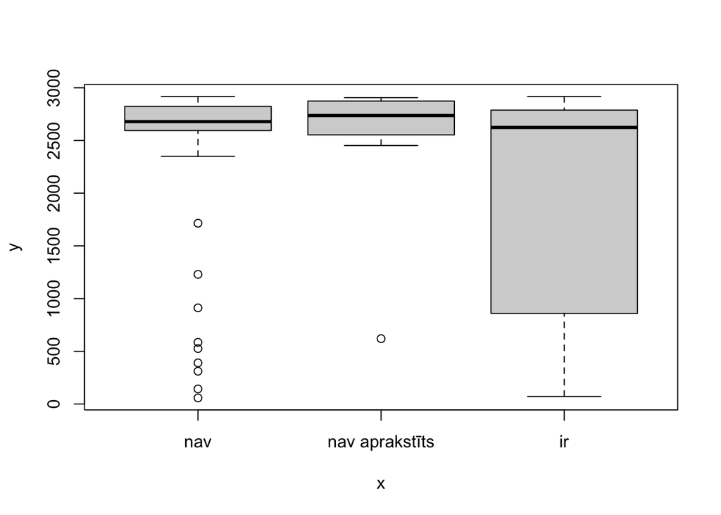

## Stadija

Sometimes “stadija” could not be deciphered. For example:

- “pT1aNxM0R0L+V-” was understood as “NA”
- “pT3bN3M0 R0L+V+” was understood as “NA”
- “pT3bN0M+ MTS pulmonem or Ca pulmonem” was understood as “NA”
- “pT4bNxM0R0IIC” was understood as “pT4bNxM0R0 IIC”.
- “^TxN3M0 IIIC MTS l/n inguinales$” was understood as “TxN3M0 IIIC”

In general, some items could be miscounted, as the “stadija” does not always follow the same pattern.

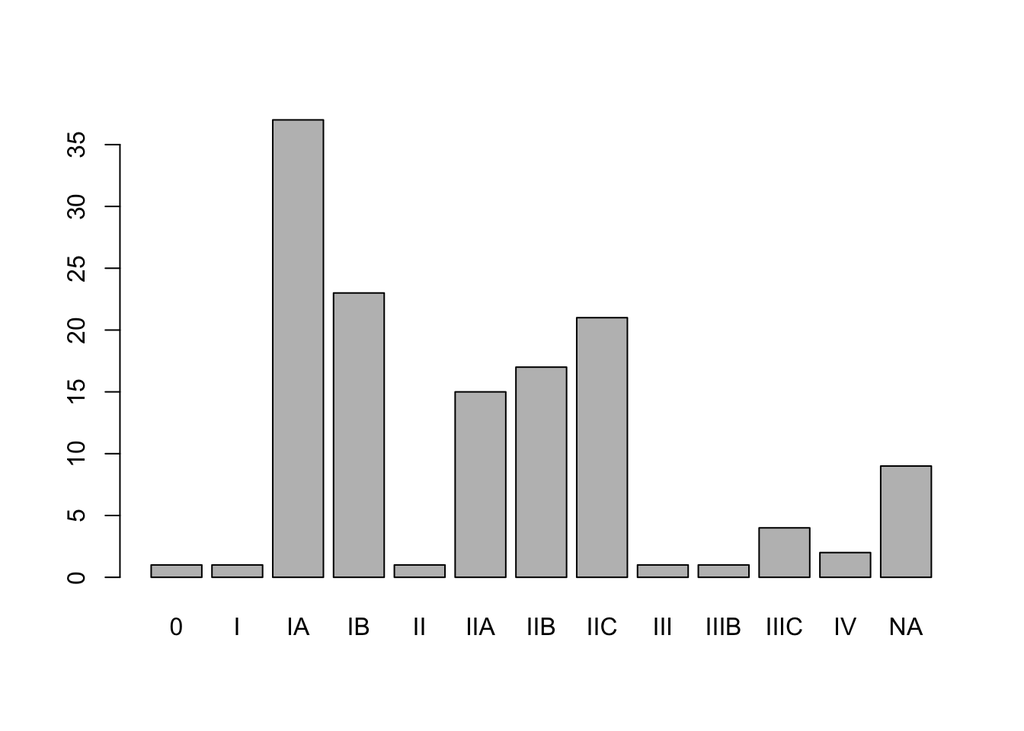

## The Parameters of Melanoma Histopatalogical Report

Here we find out how many patients as percentage (and absolute count) have histology information. And how many need additional information.

|  | Patients with this info | Count | Patients without such info | Count |
| --- | --- | --- | --- | --- |
| BreslowIndekss | 94% | N=125 | 6% | N=8 |
| KlarkaLimenis | 93% | N=124 | 7% | N=9 |
| ulceracija | 95% | N=126 | 5% | N=7 |
| mitozuSkaits | 92% | N=122 | 8% | N=11 |
| Pigmentacija | 92% | N=122 | 8% | N=11 |
| AugsRaksturs | 43% | N=57 | 57% | N=76 |
| SunuTips | 78% | N=104 | 22% | N=29 |
| invazija | 45% | N=60 | 55% | N=73 |
| mikrosateliti | 2% | N=3 | 98% | N=130 |
| RL | 96% | N=128 | 4% | N=5 |
| regresija | NA% | N=NA | NA% | N=NA |
| VGP | NA% | N=NA | NA% | N=NA |
| TIL | 56% | N=75 | 44% | N=58 |
| desmoplazija | 2% | N=3 | 98% | N=130 |